# TREE-BASED REGRESSION METHODS FOR 3D SINUSOIDAL DATA

## OVERVIEW

Using the tree-based methods to solve simple regression problems. `Gradient-Boosted Regression Tree`, `Random Forest`, and `Decision Tree` models are created and fitted to a noisy 3D sinusoidal data set. Hyperparameters are adjusted and the influence they are on the model's predictions are observed. Altering a hyperparameter in turn alters the model predictions (i.e. the prediction curve). Hyperparameter space is manually sweep to try to hone in on the optimal hyperparameter values. Then, the model predictions for the optimal `Gradient-Boosted Regression Tree`, `Random Forest`, and `Decision Tree` models were determined by the grid searches. The generalization error on the test set for the three models, which were optimally determined manually and by grid searches, are then computed.

## PRELIMINARIES

```python
#===============
# COMMON IMPORTS
#===============
import matplotlib.pyplot as plt
import matplotlib as mpl
from matplotlib import cm
import numpy as np
import pandas as pd
%matplotlib inline
mpl.rc('axes', labelsize=14)
mpl.rc('xtick', labelsize=12)
mpl.rc('ytick', labelsize=12)
import os

#=================================
# WHERE TO SAVE THE FIGURES METHOD
#=================================
PROJECT_ROOT_DIR = "."
FOLDER = "figures"
IMAGES_PATH = os.path.join(PROJECT_ROOT_DIR, FOLDER)
os.makedirs(IMAGES_PATH, exist_ok=True)
def save_fig(fig_id, tight_layout=True, fig_extension="png", resolution=300):
    path = os.path.join(IMAGES_PATH, fig_id + "." + fig_extension)
    print("Saving figure", fig_id)
    if tight_layout:
        plt.tight_layout()
    plt.savefig(path, format=fig_extension, dpi=resolution)

#================================
# PLOT SCATTER DATA POINTS METHOD
#================================
def plot3Ddata(data_df):

    #=======
    #IMPORTS
    #=======
    from mpl_toolkits.mplot3d import Axes3D
    import matplotlib.pyplot as plt

    #========
    #DATASETS
    #========
    xdata = data_df["x"]
    ydata = data_df["y"]
    zdata = data_df["z"]

    #==============
    #SIZE OF A PLOT
    #==============
    fig = plt.figure(figsize = [15, 15])

    #=========================
    #FIRST SCATTERPLOT SUBPLOT
    #=========================
    #SET UP THE AXES
    ax1 = fig.add_subplot(2, 2, 1, projection = '3d')                                #ROW 1, COLUMN 1 IN 2 ROWS 2 COLUMNS
    ax1.set_xlim(0,14)
    ax1.set_ylim(-6,6)
    #3D PLOTTING OF SCATTER DATAPOINTS
    ax1.scatter3D(xdata, ydata, zdata, c=zdata, cmap='GnBu', vmin=-2.0, vmax=0.4);   #CMAP, COLOR MAP, FOR DATAPOINTS
    #CHANGE DEFAULT VIEW ANGLE USING view_init() METHOD.
    #1ST PARAMETER IS ELEVATION ABOVE x - y PLANE.
    #2ND PARAMETER IS ROTATION COUNTER CLOCKWISE ABOUT z-AXIS
    ax1.view_init(0, 90)

    #==========================
    #SECOND SCATTERPLOT SUBPLOT
    #==========================
    #SET UP THE AXES
    ax2 = fig.add_subplot(2, 2, 2, projection = '3d')                               #ROW 1, COLUMN 2 IN 2 ROWS 2 COLUMNS
    ax2.set_xlim(0,14)
    ax2.set_ylim(-6,6)
    #3D PLOTTING OF SCATTER DATAPOINTS
    ax2.scatter3D(xdata, ydata, zdata, c=zdata, cmap='GnBu', vmin=-2.0, vmax=0.4);  #CMAP, COLOR MAP, FOR DATAPOINTS
    #CHANGE DEFAULT VIEW ANGLE USING view_init() METHOD.
    #1ST PARAMETER IS ELEVATION ABOVE x - y PLANE.
    #2ND PARAMETER IS ROTATION COUNTER CLOCKWISE ABOUT z-AXIS
    ax2.view_init(45,0)

    #=========================
    #THIRD SCATTERPLOT SUBPLOT
    #=========================
    #SET UP THE AXES
    ax3 = fig.add_subplot(2, 2, 3, projection = '3d')                                #ROW 2, COLUMN 1 IN 2 ROWS 2 COLUMNS
    ax3.set_xlim(0,14)
    ax3.set_ylim(-6,6)
    #3D PLOTTING OF SCATTER DATAPOINTS
    ax3.scatter3D(xdata, ydata, zdata, c=zdata, cmap='GnBu', vmin=-2.0, vmax=0.4);   #CMAP, COLOR MAP, FOR DATAPOINTS
    #CHANGE DEFAULT VIEW ANGLE USING view_init() METHOD.
    #1ST PARAMETER IS ELEVATION ABOVE x - y PLANE.
    #2ND PARAMETER IS ROTATION COUNTER CLOCKWISE ABOUT z-AXIS
    ax3.view_init(45, 45)

    #==========================
    #FOURTH SCATTERPLOT SUBPLOT
    #==========================
    #SET UP THE AXES
    ax4 = fig.add_subplot(2, 2, 4, projection = '3d')                                #ROW 2, COLUMN 2 IN 2 ROWS 2 COLUMNS
    ax4.set_xlim(0,14)
    ax4.set_ylim(-6,6)
    #3D PLOTTING OF SCATTER DATAPOINTS
    ax4.scatter3D(xdata, ydata, zdata, c=zdata, cmap='GnBu', vmin=-2.0, vmax=0.4);   #CMAP, COLOR MAP, FOR DATAPOINTS
    #CHANGE DEFAULT VIEW ANGLE USING view_init() METHOD.
    #1ST PARAMETER IS ELEVATION ABOVE x - y PLANE.
    #2ND PARAMETER IS ROTATION COUNTER CLOCKWISE ABOUT z-AXIS
    ax4.view_init(25,25)

    #===============
    #SET AXIS LABELS
    #===============
    ax1.set_xlabel('x')
    ax1.set_ylabel('y')
    ax1.set_zlabel('z')

    ax2.set_xlabel('x')
    ax2.set_ylabel('y')
    ax2.set_zlabel('z')

    ax3.set_xlabel('x')
    ax3.set_ylabel('y')
    ax3.set_zlabel('z')

    ax4.set_xlabel('x')
    ax4.set_ylabel('y')
    ax4.set_zlabel('z')


    plt.show()
```

```python
def plotscatter3Ddata(fit_x, fit_y, fit_z, scat_x, scat_y, scat_z):
#Numpy arrays fit_x and fit_y represent the x and y coordinates from the training data and fit_z represents
#the model predictions from those coordinates (i.e. the prediction curve). The three Numpy arrays called `scat_x, scat_y,`
#and  `scat_z` represent the x, y, and z coordinates of the training data.

    from mpl_toolkits import mplot3d
    import numpy as np
    import matplotlib.pyplot as plt

    #FIT DATA FOR 3D CURVE
    xfit = fit_x
    yfit = fit_y
    zfit = fit_z
    #TRAINING DATA
    xdata = scat_x
    ydata = scat_y
    zdata = scat_z

    #SIZE OF A PLOT
    fig = plt.figure(figsize = [15, 15])

    #=========================
    #FIRST SCATTERPLOT SUBPLOT
    #=========================
    #SET UP THE AXES
    ax1 = fig.add_subplot(2, 2, 1, projection = '3d')                                #ROW 1, COLUMN 1 IN 2 ROWS 2 COLUMNS
    ax1.set_xlim(0,14)
    ax1.set_ylim(-6,6)
    #3D PLOTTING OF SCATTER DATAPOINTS
    ax1.scatter3D(xdata, ydata, zdata, c=zdata, cmap='GnBu', vmin=-2.0, vmax=0.4);   #CMAP, COLOR MAP, FOR DATAPOINTS
    ax1.plot3D(xfit, yfit, zfit, 'black')
    #CHANGE DEFAULT VIEW ANGLE USING view_init() METHOD.
    #1ST PARAMETER IS ELEVATION ABOVE x - y PLANE.
    #2ND PARAMETER IS ROTATION COUNTER CLOCKWISE ABOUT z-AXIS
    ax1.view_init(0, 90)

    #==========================
    #SECOND SCATTERPLOT SUBPLOT
    #==========================
    #SET UP THE AXES
    ax2 = fig.add_subplot(2, 2, 2, projection = '3d')                                #ROW 1, COLUMN 2 IN 2 ROWS 2 COLUMNS
    ax2.set_xlim(0,14)
    ax2.set_ylim(-6,6)
    #3D PLOTTING OF SCATTER DATAPOINTS
    ax2.scatter3D(xdata, ydata, zdata, c=zdata, cmap='GnBu', vmin=-2.0, vmax=0.4);   #CMAP, COLOR MAP, FOR DATAPOINTS
    ax2.plot3D(xfit, yfit, zfit, 'black')
    #CHANGE DEFAULT VIEW ANGLE USING view_init() METHOD.
    #1ST PARAMETER IS ELEVATION ABOVE x - y PLANE.
    #2ND PARAMETER IS ROTATION COUNTER CLOCKWISE ABOUT z-AXIS
    ax2.view_init(45,0)

    #=========================
    #THIRD SCATTERPLOT SUBPLOT
    #=========================
    #SET UP THE AXES
    ax3 = fig.add_subplot(2, 2, 3, projection = '3d')                                #ROW 2, COLUMN 1 IN 2 ROWS 2 COLUMNS
    ax3.set_xlim(0,14)
    ax3.set_ylim(-6,6)
    #3D PLOTTING OF SCATTER DATAPOINTS
    ax3.scatter3D(xdata, ydata, zdata, c=zdata, cmap='GnBu', vmin=-2.0, vmax=0.4);   #CMAP, COLOR MAP, FOR DATAPOINTS
    ax3.plot3D(xfit, yfit, zfit, 'black')
    #CHANGE DEFAULT VIEW ANGLE USING view_init() METHOD.
    #1ST PARAMETER IS ELEVATION ABOVE x - y PLANE.
    #2ND PARAMETER IS ROTATION COUNTER CLOCKWISE ABOUT z-AXIS
    ax3.view_init(45, 45)

    #==========================
    #FOURTH SCATTERPLOT SUBPLOT
    #==========================
    #SET UP THE AXES
    ax4 = fig.add_subplot(2, 2, 4, projection = '3d')                                #ROW 2, COLUMN 2 IN 2 ROWS 2 COLUMNS
    ax4.set_xlim(0,14)
    ax4.set_ylim(-6,6)
    #3D PLOTTING OF SCATTER DATAPOINTS
    ax4.scatter3D(xdata, ydata, zdata, c=zdata, cmap='GnBu', vmin=-2.0, vmax=0.4);   #CMAP, COLOR MAP, FOR DATAPOINTS
    ax4.plot3D(xfit, yfit, zfit, 'black')
    #CHANGE DEFAULT VIEW ANGLE USING view_init() METHOD.
    #1ST PARAMETER IS ELEVATION ABOVE x - y PLANE.
    #2ND PARAMETER IS ROTATION COUNTER CLOCKWISE ABOUT z-AXIS
    ax4.view_init(25,25)

    #===============
    #SET AXIS LABELS
    #===============
    ax1.set_xlabel('x')
    ax1.set_ylabel('y')
    ax1.set_zlabel('z')

    ax2.set_xlabel('x')
    ax2.set_ylabel('y')
    ax2.set_zlabel('z')

    ax3.set_xlabel('x')
    ax3.set_ylabel('y')
    ax3.set_zlabel('z')

    ax4.set_xlabel('x')
    ax4.set_ylabel('y')
    ax4.set_zlabel('z')

    #=========
    #SHOW PLOT
    #=========
    plt.show()
```

# IMPORTING AND SPLITTING OF 3D DATA

Data from the file `3DSinusoidal.csv` was imported and return as dataframe `data`. Data was splitted with a `test_size` of 20%, and `x` and `y` are the feature data and `z` are response data, and the `random_state` parameter was `42` This is done throughout the entire notebook.

```python
#===========
#IMPORT DATA
#===========

import pandas as pd

data = pd.read_csv('3DSinusoidal.csv')

#=========================================
#SPLIT DATA INTO TRAINING AND TESTING DATA
#=========================================

import numpy as np
from sklearn.model_selection import train_test_split

#Returned columns 'x' and 'y' as feature matrix called 'X'
X = data[['x', 'y']]

#Returned column 'z' as labels called 'y'
z = data[['z']]

#Split data with test size of 20% and random state of 42. Returned as dataframes
X_train, X_test, z_train, z_test = train_test_split(X, z, test_size = 0.2, random_state = 42)
```

# SORTING THE TRAINING DATA FOR PLOTTING PREDICTIVE CURVE

```python
#==============================================================
#SORT THE TRAINING x,y,z DATA FOR PLOTTING THE PREDICTIVE CURVE
#==============================================================

#Joining dataframes X_train and y_train side by side specified by concat method with axis=1 and join='inner'
train_df = pd.concat([X_train, z_train], axis=1, join='inner')

#SORT DATAFRAME OF x,y,z TRAINING DATA FOR PLOTTING PREDICTIVE CURVE
#Sort training feature and label data by feature column 'x' in ascending order
#which results in non messy plotting of the predictive curve.
train_df_sorted = train_df.sort_values(by=['x'], ascending=True)


#AFTER SORTING, SPLIT UP DATAFRAME INTO SEPARATE x, y, AND z DATAFRAME
#Convert dataframe to numpy array
scat_x_y = np.array(train_df_sorted[['x','y']])
scat_x = np.array(train_df_sorted['x'])
scat_y = np.array(train_df_sorted['y'])
scat_z = np.array(train_df_sorted['z'])
#for fitting model
fit_x_y = np.array(train_df_sorted[['x','y']])
fit_x = np.array(train_df_sorted['x'])
fit_y = np.array(train_df_sorted['y'])
```

# PLOTTING OF RAW 3D DATA

Plot raw training data by calling the `plot3Ddata` method, which accepts a Pandas DataFrame (composed of 3 spatial coordinates) and uses `scatter3D()` to plot the data. The test set are not used here. They're used for calculating the generalization error. The graph have four subplots.

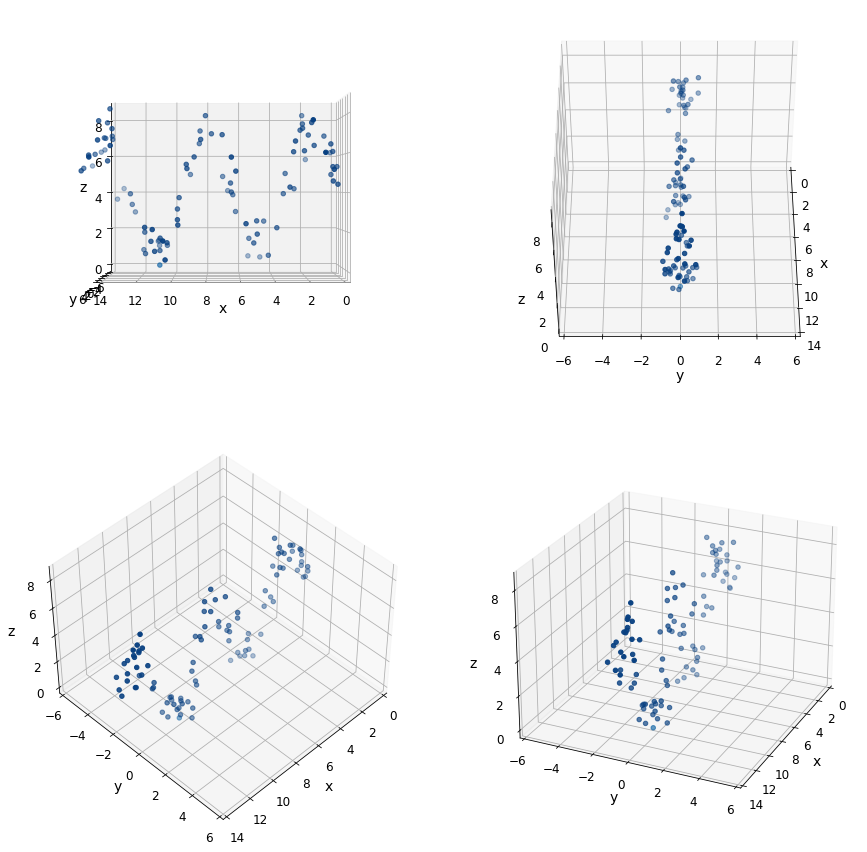

```python
#=============================================================
#PLOT 3D SCATTERPLOTS OF RAW TRAINING DATA X_train and y_train
#=============================================================

#Pass dataframe composed of X_train and y_train to plot3Ddata() method for 3D plotting of the training data
plot3Ddata(train_df)
```

# PLOTTING PREDICTIVE CURVE ON TRAINING DATA, PREDICTED USING GRADIENT BOOSTING REGRESSOR MODEL

Created and fitted a `GradientBoostingRegressor` model to this data, manually adjusting values to hone in on optimal values of following hyperparameters: `learning_rate=<value>`, `max_depth=<value>`, `n_estimators=<value>`, `random_state=42`. Manually adjusting the combination of hyperparameters until there is an optimal combination of these hyperparameters. The predictive curve on the training feature data from this model was then plotted.

```python
#========================================
#CREATE GRADIENT BOOSTING REGRESSOR MODEL
#========================================

from sklearn.ensemble import GradientBoostingRegressor

#Instantiatae object of GradientBoostingRegressor class
gbr = GradientBoostingRegressor(learning_rate=0.2, max_depth=2, n_estimators=60, random_state=42)

#Fit model with training feature data and training label data
gbr.fit(scat_x_y, scat_z)
```

```
GradientBoostingRegressor(learning_rate=0.2, max_depth=2, n_estimators=60,
                          random_state=42)
```

```python
#=======================================================
#MAKE PREDICTION USING GRADIENT BOOSTING REGRESSOR MODEL
#=======================================================

#Prediction from GradientBoostingRegressor model using training feature data instead of testing feature data
fit_z = gbr.predict(fit_x_y)
```

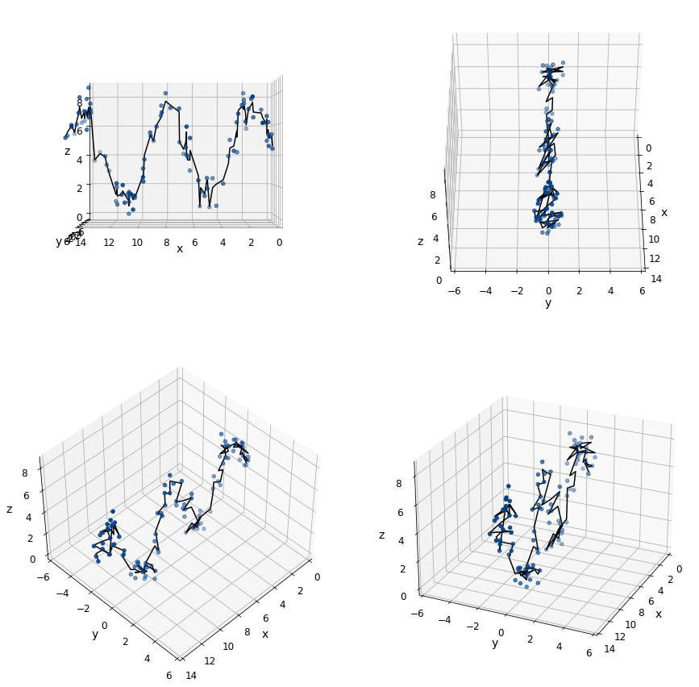

```python
#=======================================
#PLOT MODEL PREDICTIONS FOR TRAINING SET
#=======================================

#Pass training feature data, training label data, and model predictions:
#Pass training feature data: fit_x, fit_y, scat_x, scat_y
#Pass training label data: scat_z
#Pass model prediction (after fitting model): fit_z

plotscatter3Ddata(fit_x, fit_y, fit_z, scat_x, scat_y, scat_z)   # parameters passed to function are NumPy arrays
```

# PLOTTING PREDICTIVE CURVE ON TRAINING FEATURE DATA, PREDICTED USING RANDOM FOREST REGRESSOR MODEL

Created and fitted a RandomForestRegressor model to this data, manually adjusting values to hone in on optimal values of following hyperparameters: `min_samples_split=<value>`, `max_depth=<value>`, `n_estimators=<value>`, `random_state=42`. Manually adjusting the combination of hyperparameters until there is an optimal combination of these hyperparameters. The predictive curve on the training feature data from this model was then plotted.

```python
#====================================
#CREATE RANDOM FOREST REGRESSOR MODEL
#====================================

from sklearn.ensemble import RandomForestRegressor

#Instantiatae object of RandomForestRegressor class
rf_reg = RandomForestRegressor(min_samples_split=2, max_depth=6, n_estimators=1000, random_state=42)

#Fit model with training feature data and training label data
rf_reg.fit(scat_x_y, scat_z)
```

```
RandomForestRegressor(max_depth=6, n_estimators=1000, random_state=42)
```

```python
#===================================================
#MAKE PREDICTION USING RANDOM FOREST REGRESSOR MODEL
#===================================================

#Prediction from RandomForestRegressor model using training feature data instead of testing feature data
fit_z = rf_reg.predict(fit_x_y)
```

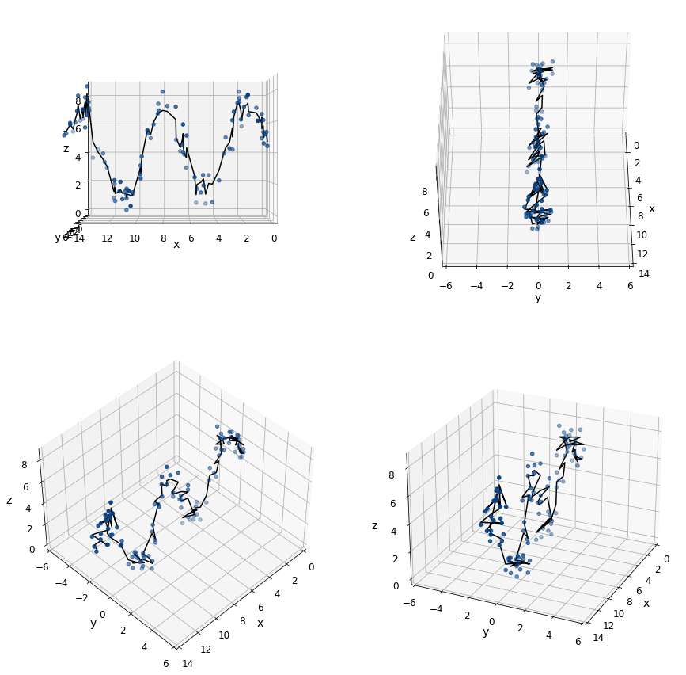

```python
#=======================================
#PLOT MODEL PREDICTIONS FOR TRAINING SET
#=======================================

#Pass training feature data, training label data, and model predictions:
#Pass training feature data: fit_x, fit_y, scat_x, scat_y
#Pass training label data: scat_z
#Pass model prediction (after fitting model): fit_z

plotscatter3Ddata(fit_x, fit_y, fit_z, scat_x, scat_y, scat_z)
```

# PLOTTING PREDICTIVE CURVE ON TRAINING FEATURE DATA, PREDICTED USING DECISION TREE REGRESSOR MODEL

```python
#====================================
#CREATE DECISION TREE REGRESSOR MODEL
#====================================

from sklearn.tree import DecisionTreeRegressor

#Instantiatae object of DecisionTreeRegressor class
tree_reg = DecisionTreeRegressor(splitter = "best", max_depth = 6, min_samples_split = 2, random_state = 42)

#Fit model with training feature data and training label data
tree_reg.fit(scat_x_y, scat_z)
```

```
DecisionTreeRegressor(max_depth=6, random_state=42)
```

```python
#===================================================
#MAKE PREDICTION USING DECISION TREE REGRESSOR MODEL
#===================================================

#Prediction from DecisionTreeRegressor model using training feature data instead of testing feature data
fit_z = tree_reg.predict(fit_x_y)
```

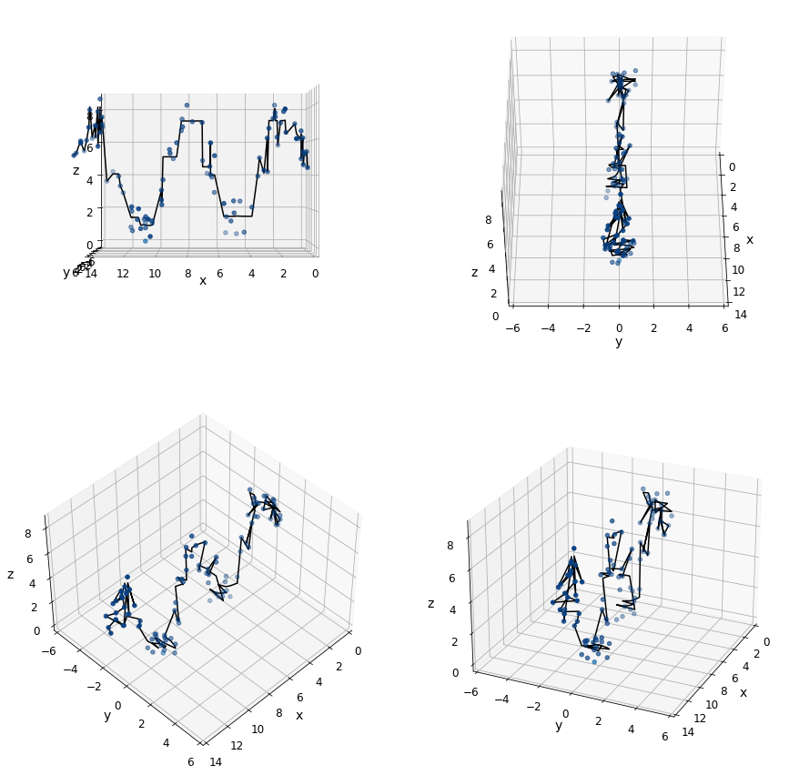

```python
#=======================================
#PLOT MODEL PREDICTIONS FOR TRAINING SET
#=======================================

#Pass training feature data, training label data, and model predictions:
#Pass training feature data: fit_x, fit_y, scat_x, scat_y
#Pass training label data: scat_z
#Pass model prediction (after fitting model): fit_z

plotscatter3Ddata(fit_x, fit_y, fit_z, scat_x, scat_y, scat_z)
```

# SERIES OF GRID SEARCHES TO YIELD OPTIMAL HYPERPARAMETER VALUES FOR EACH THREE MODELS

A series of grid searches were performed to yield the optimal hyperparameter values for each of the three model types. A comparison were made between the values of the grid search and the values that were manually found earlier. A series of grid searches (at least three): course-grained grid search, refine grid search, and a final round of grid searching.

Note the following:

1. `random_state=42` were used on all of grid searches.
1. The grid search was used to compute the following hyperparameters:

   GradientBoostingRegressor: `max_depth = <value>`, `n_estimators = <value>`, `learning_rate = <value>`

   RandomForestRegressor: `max_depth = <value>`, `n_estimators = <value>`, `min_samples_split = <value>`

   DecisionTreeRegressor: `splitter = <value>`, `max_depth = <value>`, `min_samples_split = <value>`
1. The number of cross-folds set to 3, `cv=3`

## SERIES OF GRID SEARCHES FOR GRADIENT BOOSTING REGRESSOR MODEL

```python
#===================================================
#Coarse-Grained GradientBoostingRegressor GridSearch
#===================================================

from sklearn.model_selection import GridSearchCV

#Hyperparameter values
param_grid = {'max_depth':[12,14,16,20,24,26,30,32],
              'n_estimators':[500,600,800,900,1000],
              'learning_rate':[0.05,0.08,0.1,0.3,0.5,1.0]}

#Compute optimal hyperparameter values
grid_search_cv = GridSearchCV(GradientBoostingRegressor(random_state=42), param_grid, verbose=1, cv=3)
grid_search_cv.fit(scat_x_y, scat_z)

print("The best parameters are: ", grid_search_cv.best_params_)
```

```
Fitting 3 folds for each of 240 candidates, totalling 720 fits
The best parameters are:  {'learning_rate': 1.0, 'max_depth': 12, 'n_estimators': 500}
```

```python
#============================================
#Refined GradientBoostingRegressor GridSearch
#============================================

#Hyperparameter values
param_grid = {'max_depth':[10,11,13,15],
              'n_estimators':[300,400,550,700],
              'learning_rate':[0.6,0.7,0.8,0.9]}

#Compute optimal hyperparameter values
grid_search_cv = GridSearchCV(GradientBoostingRegressor(random_state=42), param_grid, verbose=1, cv=3)
grid_search_cv.fit(scat_x_y, scat_z)

print("The best parameters are: ", grid_search_cv.best_params_)
```

```
Fitting 3 folds for each of 64 candidates, totalling 192 fits
The best parameters are:  {'learning_rate': 0.9, 'max_depth': 10, 'n_estimators': 300}
```

```python
#==========================================
#Final GradientBoostingRegressor GridSearch
#==========================================

#Hyperparameter values
param_grid = {'max_depth':[4,6,8,9],
              'n_estimators':[275,350,375],
              'learning_rate':[0.01,0.02,0.4,0.5]}

#Compute optimal hyperparameter values
grid_search_cv = GridSearchCV(GradientBoostingRegressor(random_state=42), param_grid, verbose=1, cv=3)
grid_search_cv.fit(scat_x_y, scat_z)

print("The best parameters are: ", grid_search_cv.best_params_)
```

```
Fitting 3 folds for each of 48 candidates, totalling 144 fits
The best parameters are:  {'learning_rate': 0.01, 'max_depth': 4, 'n_estimators': 275}
```

### On this Dataset, the Optimal Model Parameters for GradientBoostingRegressor Class:

- `learning_rate = 0.01`
- `max_depth = 4`
- `n_estimators = 275`

## SERIES OF GRID SEARCHES FOR RANDOM FOREST REGRESSOR MODEL

```python
#===============================================
#Coarse-Grained RandomForestRegressor GridSearch
#===============================================

from sklearn.model_selection import GridSearchCV

#Hyperparameter values
param_grid = {'max_depth':[16,20,24,26,30,32],
              'n_estimators':[300,400,500,600],
              'min_samples_split':[3,4,5,6]}

#Compute optimal hyperparameter values
grid_search_cv = GridSearchCV(RandomForestRegressor(random_state=42), param_grid, verbose=1, cv=3)
grid_search_cv.fit(scat_x_y, scat_z)

print("The best parameters are: ", grid_search_cv.best_params_)
```

```
Fitting 3 folds for each of 96 candidates, totalling 288 fits
The best parameters are:  {'max_depth': 16, 'min_samples_split': 6, 'n_estimators': 300}
```

```python
#========================================
#Refined RandomForestRegressor GridSearch
#========================================

#Hyperparameter values
param_grid = {'max_depth':[13,14,17,18],
              'n_estimators':[250,275,350,375],
              'min_samples_split':[2,6,7]}

#Compute optimal hyperparameter values
grid_search_cv = GridSearchCV(RandomForestRegressor(random_state=42), param_grid, verbose=1, cv=3)
grid_search_cv.fit(scat_x_y, scat_z)

print("The best parameters are: ", grid_search_cv.best_params_)
```

```
Fitting 3 folds for each of 48 candidates, totalling 144 fits
The best parameters are:  {'max_depth': 13, 'min_samples_split': 7, 'n_estimators': 275}
```

```python
#======================================
#Final RandomForestRegressor GridSearch
#======================================

#Hyperparameter values
param_grid = {'max_depth':[11,12,15],
              'n_estimators':[260,280,290],
              'min_samples_split':[7,8,9]}

#Compute optimal hyperparameter values
grid_search_cv = GridSearchCV(RandomForestRegressor(random_state=42), param_grid, verbose=1, cv=3)
grid_search_cv.fit(scat_x_y, scat_z)

print("The best parameters are: ", grid_search_cv.best_params_)
```

```
Fitting 3 folds for each of 27 candidates, totalling 81 fits
The best parameters are:  {'max_depth': 11, 'min_samples_split': 9, 'n_estimators': 280}
```

### On this Dataset, the Optimal Model Parameters for RandomForestRegressor Class:

- `max_depth = 11`
- `n_estimators = 280`
- `min_samples_split = 9`

## SERIES OF GRID SEARCHES FOR DECISION TREEE REGRESSOR MODEL

```python
#================================================
#Coarse-Grained DecisionTreeRegressor GridSearch
#================================================

from sklearn.model_selection import GridSearchCV

#Hyperparameter values
param_grid = {'splitter':["best", "random"],
              'max_depth':[8,10,16,20],
              'min_samples_split':[2,4,5,7]}

#Compute optimal hyperparameter values
grid_search_cv = GridSearchCV(DecisionTreeRegressor(random_state=42), param_grid, verbose=1, cv=3)
grid_search_cv.fit(scat_x_y, scat_z)

print("The best parameters are: ", grid_search_cv.best_params_)
```

```
Fitting 3 folds for each of 32 candidates, totalling 96 fits
The best parameters are:  {'max_depth': 10, 'min_samples_split': 7, 'splitter': 'random'}
```

```python
#========================================
#Refined DecisionTreeRegressor GridSearch
#========================================

#Hyperparameter values
param_grid = {'splitter':["best", "random"],
              'max_depth':[9,11,15],
              'min_samples_split':[6,7,8]}

#Compute optimal hyperparameter values
grid_search_cv = GridSearchCV(DecisionTreeRegressor(random_state=42), param_grid, verbose=1, cv=3)
grid_search_cv.fit(scat_x_y, scat_z)

print("The best parameters are: ", grid_search_cv.best_params_)
```

```
Fitting 3 folds for each of 18 candidates, totalling 54 fits
The best parameters are:  {'max_depth': 11, 'min_samples_split': 7, 'splitter': 'random'}
```

```python
#========================================
#Final DecisionTreeRegressor GridSearch
#========================================

#Hyperparameter values
param_grid = {'splitter':["best", "random"],
              'max_depth':[7,12,13],
              'min_samples_split':[7,9,12]}

#Compute optimal hyperparameter values
grid_search_cv = GridSearchCV(DecisionTreeRegressor(random_state=42), param_grid, verbose=1, cv=3)
grid_search_cv.fit(scat_x_y, scat_z)

print("The best parameters are: ", grid_search_cv.best_params_)
```

```
Fitting 3 folds for each of 18 candidates, totalling 54 fits
The best parameters are:  {'max_depth': 12, 'min_samples_split': 7, 'splitter': 'random'}
```

### On this Dataset, the Optimal Model Parameters for DecisionTreeRegressor Class:

- `splitter = random`
- `max_depth = 12`
- `min_samples_split = 7`

# PLOTTING PREDICTIVE CURVE FOR EACH MODEL AFTER THEY WENT THROUGH A SERIES OF GRID SEARCHES THAT COMPUTED THE OPTIMAL HYPERPARAMETERS FOR IT

**best*params* attribute of the grid search objects from above were used to create the three optimal models**

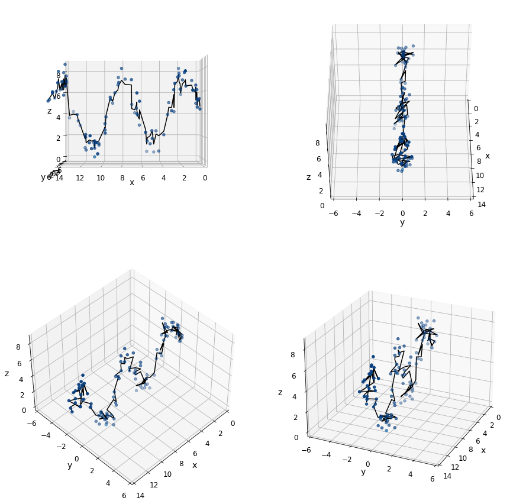

```python
#==============================================================================================================
#Create optimal GradientBoostingRegressor model using best hyperparameters which resulted from final GridSearch
#==============================================================================================================
gbrt_after_gridsearch = GradientBoostingRegressor(max_depth=4, n_estimators=275, learning_rate=0.01, random_state=42)
gbrt_after_gridsearch.fit(scat_x_y, scat_z)

#=========================================================================
#Plot optimal GradientBoostingRegressor model predictions for training set
#=========================================================================

#Make model prediction from GradientBoostingRegressor model using training feature data instead of testing feature data
fit_z = gbrt_after_gridsearch.predict(fit_x_y)

#Call plotscatter3Ddata() method defined above
#Pass training feature data, training label data, and model predictions:
#Pass training feature data: fit_x, fit_y, scat_x, scat_y
#Pass training label data: scat_z
#Pass model prediction (after fitting model): fit_z
plotscatter3Ddata(fit_x, fit_y, fit_z, scat_x, scat_y, scat_z)
```

### PLOTTING PREDICTIVE CURVE FOR RANDOM FOREST REGRESSOR MODEL AFTER IT WENT THROUGH A SERIES OF GRID SEARCHES

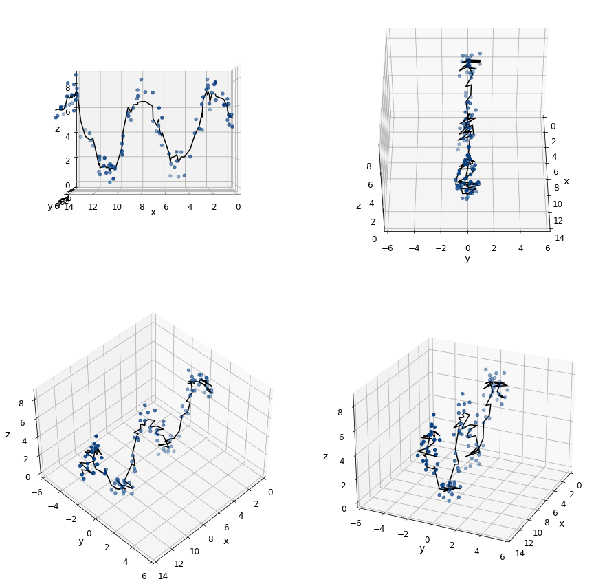

```python
#==========================================================================================================
#Create optimal RandomForestRegressor model using best hyperparameters which resulted from final GridSearch
#==========================================================================================================
rf_reg_after_gridsearch = RandomForestRegressor(max_depth=11, n_estimators=280, min_samples_split=9, random_state=42)
rf_reg_after_gridsearch.fit(scat_x_y, scat_z)

#=====================================================================
#Plot optimal RandomForestRegressor model predictions for training set
#=====================================================================

#Make model prediction from RandomForestRegressor model using training feature data instead of testing feature data
fit_z = rf_reg_after_gridsearch.predict(fit_x_y)

#Call plotscatter3Ddata() method defined above
#Pass training feature data, training label data, and model predictions:
#Pass training feature data: fit_x, fit_y, scat_x, scat_y
#Pass training label data: scat_z
#Pass model prediction (after fitting model): fit_z
plotscatter3Ddata(fit_x, fit_y, fit_z, scat_x, scat_y, scat_z)
```

### PLOTTING PREDICTIVE CURVE FOR DECISION TREE REGRESSOR MODEL AFTER IT WENT THROUGH A SERIES OF GRID SEARCHES

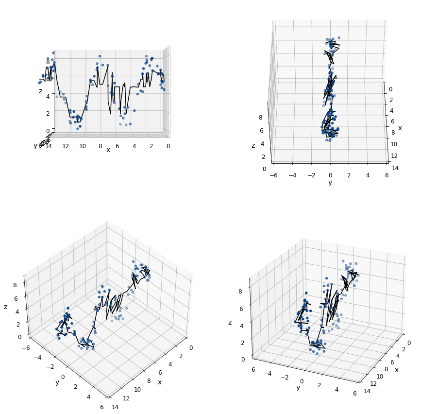

```python
#==========================================================================================================
#Create optimal DecisionTreeRegressor model using best hyperparameters which resulted from final GridSearch
#==========================================================================================================
tree_reg_after_gridsearch = DecisionTreeRegressor(splitter='random', max_depth=12, min_samples_split=7, random_state=42)
tree_reg_after_gridsearch.fit(scat_x_y, scat_z)

#=====================================================================
#Plot optimal DecisionTreeRegressor model predictions for training set
#=====================================================================

#Make model prediction from DecisionTreeRegressor model using training feature data instead of testing feature data
fit_z = tree_reg_after_gridsearch.predict(fit_x_y)

#Call plotscatter3Ddata() method defined above
#Pass training feature data, training label data, and model predictions:
#Pass training feature data: fit_x, fit_y, scat_x, scat_y
#Pass training label data: scat_z
#Pass model prediction (after fitting model): fit_z
plotscatter3Ddata(fit_x, fit_y, fit_z, scat_x, scat_y, scat_z)
```

# GENERALIZATION ERROR

**Generalization error, using MSE as the generalization error metric, for each of the optimal models that were both manually adjusted and determined by grid searches.**

```python
#==============================================================================
#GENERALIZATION ERROR FOR OPTIMAL MODELS USING MSE, MEAN SQUARED ERROR, MEASURE
#==============================================================================

from sklearn.metrics import mean_squared_error

# True labels
z_true = z_test

#============================================================================================
#MSE FOR EACH OPTIMAL MODEL THAT HAS BEST HYPERPARAMETER VALUES AFTER ADJUSTING THEM MANUALLY
#============================================================================================

#Predictions on a dataset using each optimal model
z_preds_gbrt = gbr.predict(X_test)                                   # from optimal GradientBoostingRegressor model
z_preds_rf = rf_reg.predict(X_test)                                  # from optimal RandomForestRegressor model
z_preds_tree = tree_reg.predict(X_test)                              # from optimal DecisionTreeRegressor model

#MSE for those optimal models, using true z-labels and predictions
MSE_gbrt = mean_squared_error(z_true, z_preds_gbrt)                    # MSE for optimal GradientBoostingRegressor model
MSE_rf_reg = mean_squared_error(z_true, z_preds_rf)                    # MSE for optimal RandomForestRegressor model
MSE_tree_reg = mean_squared_error(z_true, z_preds_tree)                # MSE for optimal DecisionTreeRegressor model

#Answers rounded to four significant digits
MSE_gbrt = round(MSE_gbrt, 3)
MSE_rf_reg = round(MSE_rf_reg, 3)
MSE_tree_reg = round(MSE_tree_reg, 3)


#=================================================================================================
#MSE FOR EACH OPTIMAL MODEL THAT HAS BEST HYPERPARAMETER VALUES AFTER IT WENT THROUGH A GRIDSEARCH
#=================================================================================================

#Predictions on a dataset using each optimal model
z_preds_gbrt_after_gridsearch = gbrt_after_gridsearch.predict(X_test)        # from optimal GradientBoostingRegressor model after grid search
z_preds_rf_after_gridsearch = rf_reg_after_gridsearch.predict(X_test)        # from optimal RandomForestRegressor model after grid search
z_preds_tree_after_gridsearch = tree_reg_after_gridsearch.predict(X_test)    # from optimal DecisionTreeRegressor model after grid search

#MSE for those optimal models, using true z-labels and predictions
MSE_gbrt_after_gridsearch = mean_squared_error(z_true, z_preds_gbrt_after_gridsearch)     # MSE for optimal GradientBoostingRegressor model after grid search
MSE_rf_reg_after_gridsearch = mean_squared_error(z_true, z_preds_rf_after_gridsearch)     # MSE for optimal RandomForestRegressor model after grid search
MSE_tree_reg_after_gridsearch = mean_squared_error(z_true, z_preds_tree_after_gridsearch) # MSE for optimal DecisionTreeRegressor model after grid search

#Answers rounded to four significant digits
MSE_gbrt_after_gridsearch = round(MSE_gbrt_after_gridsearch, 3)
MSE_rf_reg_after_gridsearch = round(MSE_rf_reg_after_gridsearch, 3)
MSE_tree_reg_after_gridsearch = round(MSE_tree_reg_after_gridsearch, 3)

#Display each MSE
print("MSE FOR FOLLOWING OPTIMAL MODELS:\n")
print("GradientBoostingRegressor model after adjusting hyperparameters manually: ", MSE_gbrt)
print("GradientBoostingRegressor model after gridsearch:                         ", MSE_gbrt_after_gridsearch)
print("\nRandomForestRegressor model after adjusting hyperparameters manually:     ", MSE_rf_reg)
print("RandomForestRegressor model after gridsearch:                             ", MSE_rf_reg_after_gridsearch)
print("\nDecisionTreeRegressor model after adjusting hyperparameters manually:     ", MSE_tree_reg)
print("DecisionTreeRegressor model after gridsearch:                             ", MSE_tree_reg_after_gridsearch)
```

```
MSE FOR FOLLOWING OPTIMAL MODELS:

GradientBoostingRegressor model after adjusting hyperparameters manually:  0.469
GradientBoostingRegressor model after gridsearch:                          0.564

RandomForestRegressor model after adjusting hyperparameters manually:      0.54
RandomForestRegressor model after gridsearch:                              0.471

DecisionTreeRegressor model after adjusting hyperparameters manually:      0.954
DecisionTreeRegressor model after gridsearch:                              3.337
```